# **GOAL: Analyse lending data to identify the variables that are strong indicators of default**

# Step 1 - load the data

```python
import os
```

```python
os.getcwd()
```

```
'/content'
```

```python
import numpy as np
import pandas as pd
import matplotlib.pyplot as plt
import datetime
import seaborn as sns

original_data = pd.read_csv('loan.csv')
original_data.shape
```

```
(39717, 111)
```

```python
original_data.head()
```

|  | id | member_id | loan_amnt | funded_amnt | funded_amnt_inv | term | int_rate | installment | grade | sub_grade | ... | num_tl_90g_dpd_24m | num_tl_op_past_12m | pct_tl_nvr_dlq | percent_bc_gt_75 | pub_rec_bankruptcies | tax_liens | tot_hi_cred_lim | total_bal_ex_mort | total_bc_limit | total_il_high_credit_limit |
| --- | --- | --- | --- | --- | --- | --- | --- | --- | --- | --- | --- | --- | --- | --- | --- | --- | --- | --- | --- | --- | --- |
| 0 | 1077501 | 1296599 | 5000 | 5000 | 4975.0 | 36 months | 10.65% | 162.87 | B | B2 | ... | NaN | NaN | NaN | NaN | 0.0 | 0.0 | NaN | NaN | NaN | NaN |
| 1 | 1077430 | 1314167 | 2500 | 2500 | 2500.0 | 60 months | 15.27% | 59.83 | C | C4 | ... | NaN | NaN | NaN | NaN | 0.0 | 0.0 | NaN | NaN | NaN | NaN |
| 2 | 1077175 | 1313524 | 2400 | 2400 | 2400.0 | 36 months | 15.96% | 84.33 | C | C5 | ... | NaN | NaN | NaN | NaN | 0.0 | 0.0 | NaN | NaN | NaN | NaN |
| 3 | 1076863 | 1277178 | 10000 | 10000 | 10000.0 | 36 months | 13.49% | 339.31 | C | C1 | ... | NaN | NaN | NaN | NaN | 0.0 | 0.0 | NaN | NaN | NaN | NaN |
| 4 | 1075358 | 1311748 | 3000 | 3000 | 3000.0 | 60 months | 12.69% | 67.79 | B | B5 | ... | NaN | NaN | NaN | NaN | 0.0 | 0.0 | NaN | NaN | NaN | NaN |

5 rows × 111 columns

Step 2: Data Cleaning

Step 2.1: Drop empty columns

```python
# Remove columns that have no data
# 1>count nulls : original_data.isnull().sum()
# 2>percentage of nulls in a column: original_data.isnull().sum()/len(original_data.index)
nodata_columns = original_data.columns[100*(original_data.isnull().sum()/len(original_data.index)) == 100]

original_data.drop(columns=nodata_columns, inplace=True)
original_data.shape
```

```
(39717, 57)
```

Step 2.2: Drop columns that don't add value

Continuing with the above theme, we can see that there are a few columns that only one value. They arent much useful in the analysis. Make a note of such columns, just in case, and then remove the same

```python
ignore_columns = [column for column in original_data.columns if len(original_data[column].value_counts()) < 2]

# Column acc_now_delinq = The number of accounts on which the borrower is now delinquent
print(original_data.acc_now_delinq.value_counts()) # all 0

# Column application_type = individual application or a joint application
print('\n', original_data.application_type.value_counts()) # all INDIVIDUAL

# Column initial_list_status = The initial listing status of the loan. Possible values are – W, F
print('\n', original_data.initial_list_status.value_counts()) # all f

# Column policy_code = publicly available policy_code=1
print('\n', original_data.policy_code.value_counts()) # all 1

# Column pymnt_plan = Indicates if a payment plan has been put in place for the loan
print('\n', original_data.pymnt_plan.value_counts()) # all n

# 'collections_12_mths_ex_med', 'chargeoff_within_12_mths','tax_liens'
print('\n', original_data.collections_12_mths_ex_med.value_counts()) # all 0.0 or na
print('\n', original_data.chargeoff_within_12_mths.value_counts())
print('\n', original_data.tax_liens.value_counts())

# Grade and subgrade are a LC construct. While grade may be analysed as an indicator of LC analysis bias, we can ignore subgrade for now.
# Similarly, the columns funded_amnt and funded_amnt_inv may be ignored for now.

# ignore_columns = ['acc_now_delinq', 'application_type', 'initial_list_status', 'policy_code', 'pymnt_plan','funded_amnt', 'funded_amnt_inv', 'sub_grade','collections_12_mths_ex_med', 'chargeoff_within_12_mths','tax_liens']
original_data.drop(columns=ignore_columns, inplace=True)
```

```
0    39717
Name: acc_now_delinq, dtype: int64

 INDIVIDUAL    39717
Name: application_type, dtype: int64

 f    39717
Name: initial_list_status, dtype: int64

 1    39717
Name: policy_code, dtype: int64

 n    39717
Name: pymnt_plan, dtype: int64

 0.0    39661
Name: collections_12_mths_ex_med, dtype: int64

 0.0    39661
Name: chargeoff_within_12_mths, dtype: int64

 0.0    39678
Name: tax_liens, dtype: int64
```

Step 2.3 Sanity Checks

nunique() - This function is used to get total number of unique categories present in single column

The nunique() method returns the number of unique values for each column.

By specifying the column axis ( axis='columns' ), the nunique() method searches column-wise and returns the number of unique values for each row.

```python
# check ids are unique
print(original_data.id.nunique()) # all unique values

# The addresses seem to be from US. There should not be more than 50 unique states
# check addr_state to confirm the above
print(original_data.addr_state.nunique()) # 50 as expected

print(original_data.member_id.nunique()) # all unique values

print(original_data.term.value_counts()) # 36 or 60. Checks out

print(original_data.loan_amnt.describe())
# Max amount is 35000, min is 500. This falls in the range that LC lending operates in. Checks out

# Drop url => Since we have id column to identify an application, we wont need the url column
# Drop member_id => it isnt useful for this analysis
# Drop emp_title => this columns may be useful for borrower verification and isnt useful per the constraints of this case study
# Drop zip_code => same as above
# Drop title, desc => freetext /comments entered by user
# Drop out_prncp, out_prncp_inv => Remaining outstanding principal columns are not available at application time. Hence cannot be used to predict if user will default
# Drop total_pymnt,total_pymnt_inv,total_rec_prncp,total_rec_int,total_rec_late_fee => Similarly ignore these (Payments received to date) columns
# Drop 'last_pymnt_d', 'last_pymnt_amnt', 'next_pymnt_d'
# Drop recoveries, collection_recovery_fee because these columns only pertain to loans that have been marked as charged off.
# Drop funded_amnt_inv = this is the amount funded by investor. Since we have loan_amt and funded_amt, its unlikely this column will add more info to the analysis.
ignore_columns = ['url', 'member_id', 'emp_title', 'zip_code', 'title', 'desc','out_prncp','out_prncp_inv','total_pymnt','total_pymnt_inv','total_rec_prncp','total_rec_int','total_rec_late_fee', 'last_pymnt_d', 'last_pymnt_amnt', 'next_pymnt_d','recoveries', 'collection_recovery_fee', 'funded_amnt_inv']
original_data.drop(columns=ignore_columns, inplace=True)
```

```
39717
50
39717
 36 months    29096
 60 months    10621
Name: term, dtype: int64
count    39717.000000
mean     11219.443815
std       7456.670694
min        500.000000
25%       5500.000000
50%      10000.000000
75%      15000.000000
max      35000.000000
Name: loan_amnt, dtype: float64
```

Step 2.4 Missing values

isnull() - This will retrun blank rows from dataframe

sum() - This will return sum of null cells in dataframe

missing_data varible = % of NULL value

```python
# % of missing values
missing_data = 100*(original_data.isnull().sum()/len(original_data.index))
print(missing_data)

# Lets handle these case by case in the following cells
```

```
id                         0.000000
loan_amnt                  0.000000
funded_amnt                0.000000
term                       0.000000
int_rate                   0.000000
installment                0.000000
grade                      0.000000
sub_grade                  0.000000
emp_length                 2.706650
home_ownership             0.000000
annual_inc                 0.000000
verification_status        0.000000
issue_d                    0.000000
loan_status                0.000000
purpose                    0.000000
addr_state                 0.000000
dti                        0.000000
delinq_2yrs                0.000000
earliest_cr_line           0.000000
inq_last_6mths             0.000000
mths_since_last_delinq    64.662487
mths_since_last_record    92.985372
open_acc                   0.000000
pub_rec                    0.000000
revol_bal                  0.000000
revol_util                 0.125891
total_acc                  0.000000
last_credit_pull_d         0.005036
pub_rec_bankruptcies       1.754916
dtype: float64
```

```python
# Missing-values columns Step 1 - Columns mths_since_last_record and mths_since_last_delinq are not usable. We can drop them
original_data.drop(columns=['mths_since_last_record', 'mths_since_last_delinq'], inplace=True)

# Missing-values columns Step 2 - Column pub_rec_bankruptcies
print(original_data.pub_rec_bankruptcies.describe()) # most values are 0 (even 3rd quartile)
# we can safely impute missing values with 0
original_data.pub_rec_bankruptcies.fillna(0, inplace=True)
```

```
count    39020.000000
mean         0.043260
std          0.204324
min          0.000000
25%          0.000000
50%          0.000000
75%          0.000000
max          2.000000
Name: pub_rec_bankruptcies, dtype: float64
```

```python
# Missing-values columns Step 3
print(original_data.emp_length.value_counts(), original_data.emp_length.describe())
print('\n', original_data.revol_util.value_counts(), original_data.revol_util.describe())
print('\n', original_data.last_credit_pull_d.value_counts(), original_data.last_credit_pull_d.describe())

# By looking at the mean mode median for the above columns,
# we take a call to let them be as is(without imputation)
```

```
10+ years    8879
< 1 year     4583
2 years      4388
3 years      4095
4 years      3436
5 years      3282
1 year       3240
6 years      2229
7 years      1773
8 years      1479
9 years      1258
Name: emp_length, dtype: int64 count         38642
unique           11
top       10+ years
freq           8879
Name: emp_length, dtype: object

 0%        977
0.20%      63
63%        62
40.70%     58
66.70%     58
         ...
25.74%      1
47.36%      1
24.65%      1
10.61%      1
7.28%       1
Name: revol_util, Length: 1089, dtype: int64 count     39667
unique     1089
top          0%
freq        977
Name: revol_util, dtype: object

 May-16    10308
Apr-16     2547
Mar-16     1123
Feb-13      843
Feb-16      736
          ...
May-08        1
Jun-08        1
Jul-08        1
May-07        1
Jul-07        1
Name: last_credit_pull_d, Length: 106, dtype: int64 count      39715
unique       106
top       May-16
freq       10308
Name: last_credit_pull_d, dtype: object
```

Step 2.5: Column data type transformations

astype('float') - It will convert integer column to float

```python
# 1 - Columns int_Rate and revol_util are like 10.41%. Convert to type float
original_data.int_rate = original_data.int_rate.str[:-1].astype('float')
original_data.revol_util = original_data.revol_util.str[:-1].astype('float')
```

```python
# 2 Columns issue_d, earliest_cr_line have data like Jan-85.
# Now we could convert them to proper date with day as 1st.

def to_datetime(x):
    (month, year)=x.strip().split('-')
    year = int(year)
    if year > 20:
        year = 1900+year
    else:
        year = 2000+ year
    x = '-'.join(['01',month,str(year)])
    return datetime.datetime.strptime(x,'%d-%b-%Y')

def to_month(x):
    x = to_datetime(x)
    return x.month

def to_year(x):
    x = to_datetime(x)
    return x.year

original_data['earliest_cr_line_year'] = original_data.earliest_cr_line.apply(to_year)
original_data['earliest_cr_line_month'] = original_data.earliest_cr_line.apply(to_month)

original_data['issue_d_year'] = original_data.issue_d.apply(to_year)
original_data['issue_d_month'] = original_data.issue_d.apply(to_month)

original_data.drop(columns=['earliest_cr_line', 'issue_d'], inplace=True)
```

Step 2.6 Filtering data

Since our target is to analyse factors that indicate default, we can ignore records that have loan_status as Current

```python
# lets filter out loan_status that are current
original_data = original_data[original_data.loan_status != 'Current']
```

Step 3 Univariate Analysis

Univariate Analysis is the analysis of single CATEGORICAL columns separately

['term', 'home_ownership','purpose', 'emp_length','verification_status', 'grade'] = these columns will be analyzed separately and plots categories of each variable in horizontal bar graph [[kind='barh']]

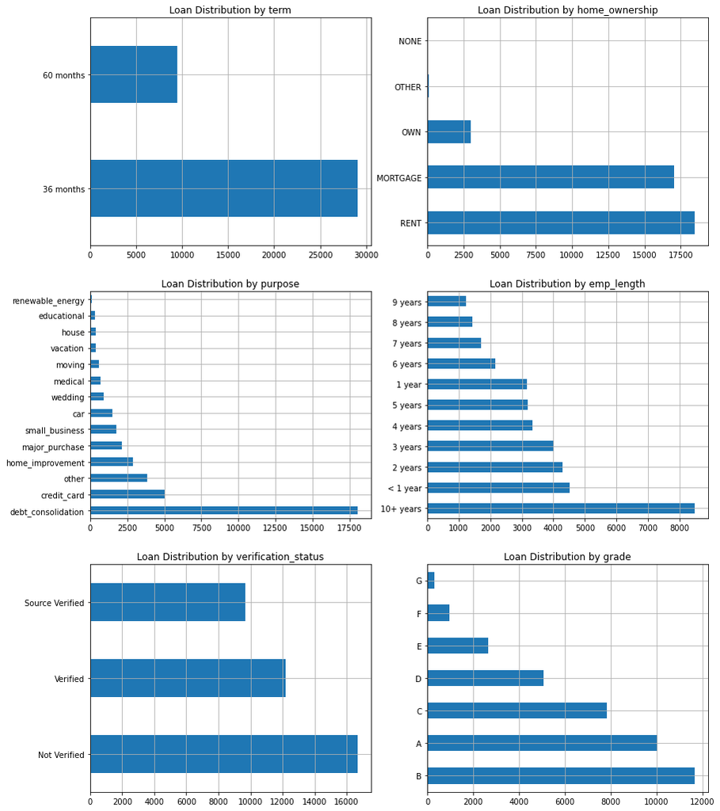

```python
# Lets checkout the catagorical variables
uni_cols=['term', 'home_ownership','purpose', 'emp_length','verification_status', 'grade']
ncol=2
nrow=int(round(len(uni_cols)/2,0))

# make a list of all dataframes
df_list = [original_data[x] for x in uni_cols]

fig, axes = plt.subplots(nrow, ncol,figsize=(7*ncol, 6 * nrow))
# plot counter
count=0
for r in range(nrow):
    for c in range(ncol):
        if count < len(uni_cols):
            df_list[count].value_counts().plot(ax=axes[r,c], kind='barh',grid=True, title=('Loan Distribution by '+uni_cols[count]))
        count= count+1

plt.show()
```

Univariate analysis of numerical variable bin_annual_salary function is used to create Nummeric income to income_category

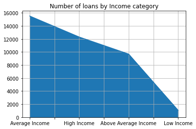

```python
# Lets segment annual_inc to bins
def bin_annual_salary(sal):
    sal = sal / 1000
    if sal < 20:
        return 'Low Income'
    elif sal < 53:
        return 'Average Income'
    elif sal < 75:
        return 'Above Average Income'
    else:
        return 'High Income'
original_data['income_category'] = original_data.annual_inc.apply(bin_annual_salary)

original_data.income_category.value_counts().plot.area(grid=True, title='Number of loans by Income category')
plt.show()
```

Univariate analysis of numerical variable

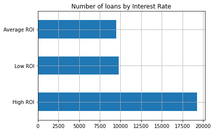

```python
original_data['int_rate_category'] = pd.qcut(original_data.int_rate, q=[0,0.25,0.50,1],labels=['Low ROI','Average ROI','High ROI'])

original_data['int_rate_category'].value_counts().plot(kind='barh', grid=True, title='Number of loans by Interest Rate')
plt.show()
```

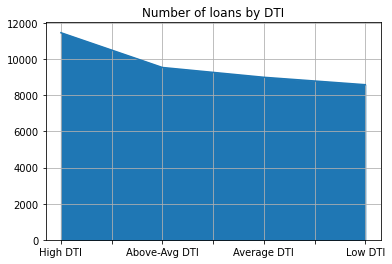

```python
def bin_dti(value):
    value = round(value,0)
    if value < 8:
        return 'Low DTI'
    elif value < 13:
        return 'Average DTI'
    elif value < 18:
        return 'Above-Avg DTI'
    else:
        return 'High DTI'

original_data['dti_category'] = original_data.dti.apply(bin_dti)
original_data['dti_category'].value_counts().plot(kind='area', grid=True, title='Number of loans by DTI')
plt.show()
```

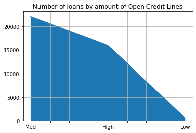

```python
def bin_openacc(value):
    if value <= 2:
        return "Low"
    elif value <= 9:
        return "Med"
    else:
        return 'High'

original_data['open_acc_category'] = original_data.open_acc.apply(bin_openacc)
original_data['open_acc_category'].value_counts().plot(kind='area', grid=True, title='Number of loans by amount of Open Credit Lines')
plt.show()
```

```python
original_data.revol_util.describe()
```

```
count    38527.000000
mean        48.702777
std         28.364741
min          0.000000
25%         25.200000
50%         49.100000
75%         72.300000
max         99.900000
Name: revol_util, dtype: float64
```

```python
# Segment quatitative variable revol_util
original_data['revol_util_category'] = pd.qcut(original_data.revol_util, q=[0,0.50,1],labels=['Avg(Revol Util)','High(Revol Util)'])
```

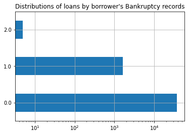

```python
# Lets visualize the number of loans against number of public bankruptcies
original_data['pub_rec_bankruptcies'].value_counts().plot(kind='barh', logx=True, grid=True, title="Distributions of loans by borrower's Bankruptcy records")
plt.show()
```

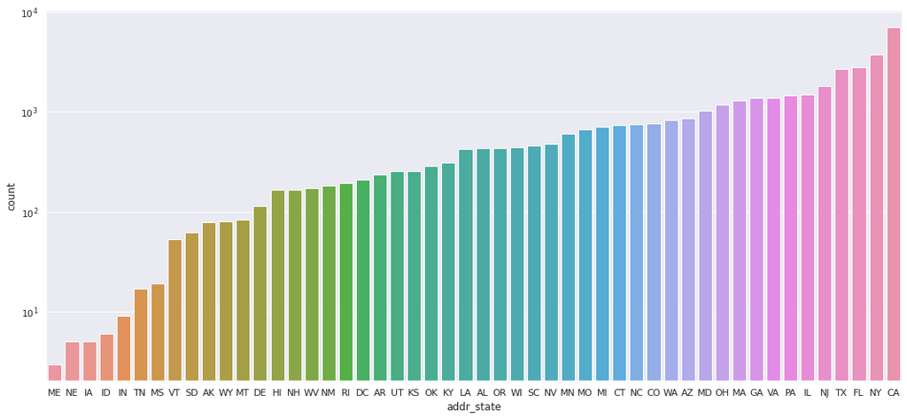

```python
# Lets see the distribution of loans by borrower's (address) state
sns.set(style="darkgrid")
df = original_data[['id','addr_state','loan_status']]
plt.figure(figsize=(18,8))
ax = sns.countplot(x=df['addr_state'], log=True, order=df['addr_state'].value_counts(ascending=True).index)
plt.show()
```

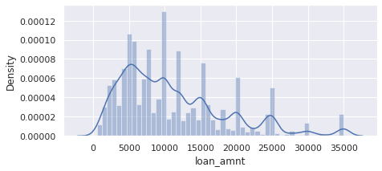

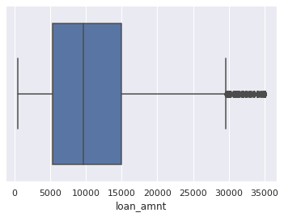

```python
# Visually analyse loan amount
f, ax = plt.subplots(figsize=(7, 3))
ax = sns.distplot(original_data['loan_amnt'])
plt.show();
ax = sns.boxplot(x=original_data['loan_amnt'])
plt.show();

#This graph verifies our sanity check. Max loan amount is 35000 (a LC constraint).
```

```
count    38577.000000
mean       322.466318
std        208.639215
min         15.690000
25%        165.740000
50%        277.860000
75%        425.550000
max       1305.190000
Name: installment, dtype: float64
```

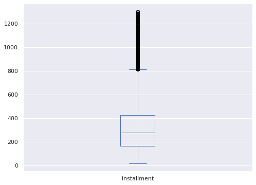

```python
# Let's check the distribution of installment amount
print(original_data['installment'].describe())
original_data['installment'].plot(kind='box', figsize=(8,6), grid=True)
plt.show()
```

Analysis for indicator variables

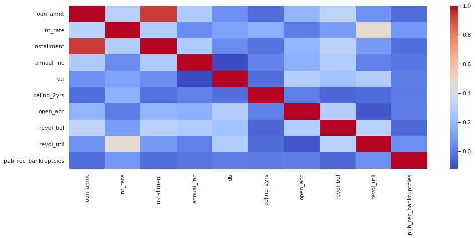

```python
# lets first try to plot a correlation map
col_for_correlation = ['loan_amnt','int_rate', 'installment','annual_inc','dti', 'delinq_2yrs', 'open_acc', 'revol_bal', 'revol_util', 'pub_rec_bankruptcies']
plt.figure(figsize=(16,6))
corr = original_data[col_for_correlation].corr()
sns.heatmap(corr,
            xticklabels=corr.columns.values,
            yticklabels=corr.columns.values,cmap = 'coolwarm')
plt.show()
# There doesnt seem to be any quality correlation between the non-obvious variables.
```

```python
# This method plots the percentage of loans fully paid and charged off as a stacked chart for a given column
def custom_stacked_chart_by_loanstatues(column, size=(8,5), chartkind='bar',theme='viridis'):
    pivot_df = original_data.pivot_table(index=column, columns='loan_status', values='id',aggfunc=len, margins=True,margins_name='Total')
    pivot_df = pivot_df.div( pivot_df.iloc[:,-1], axis=0 ).mul(100, axis=0)
    pivot_df.drop(columns='Total', inplace=True)
    pivot_df = pivot_df[0:-1]
    pivot_df.sort_values('Charged Off', inplace=True)
    pivot_df.plot(kind=chartkind, stacked=True, grid=True, figsize=size, colormap=theme)
    plt.show()
```

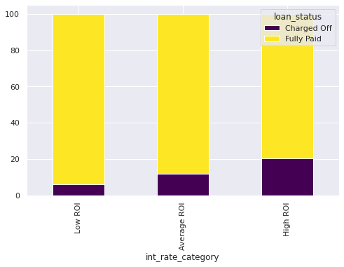

```python
# Lets checkout effect of int_rate_category on loan status

custom_stacked_chart_by_loanstatues('int_rate_category')

# This shows borrowers with high interest rate are more lifely to default
```

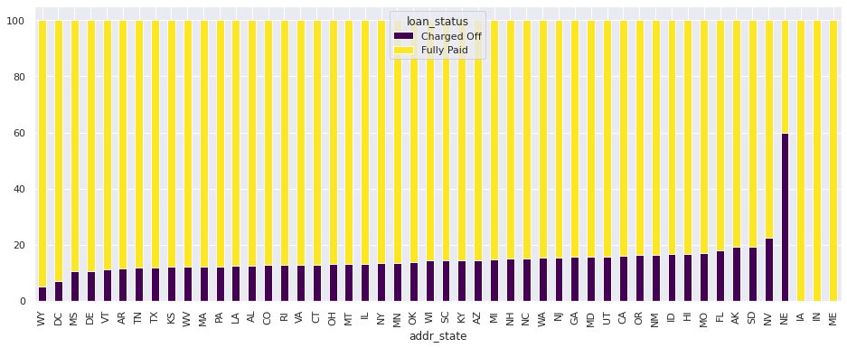

```python
# Lets checkout effect of addr_state on loan status

custom_stacked_chart_by_loanstatues('addr_state', size=(16,6))

# This shows that borrowers from the states of NE (Nebraska), NV(Nevada), SD(South Dakota) and AK (Alaska) are more likely to default
```

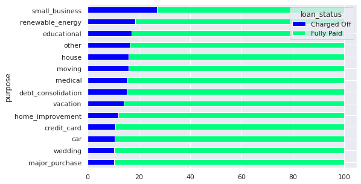

```python
# Lets checkout effect of addr_state on loan status

custom_stacked_chart_by_loanstatues('purpose', chartkind='barh', theme='winter')

# Application with purpose Small Business, Renewable Energy, Educational and Others are at risk to default
# But by our Univariate analysis, we see that the amount of loans granted for Others and Small Business are higher than for the Reneweable and Educational
```

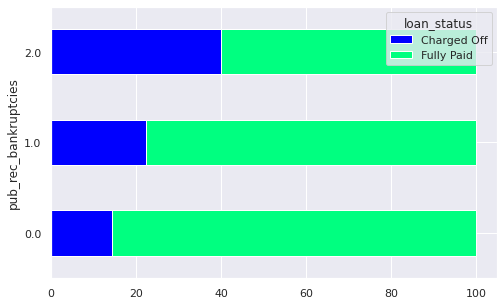

```python
# Lets checkout effect of bankruptcies levels on loan status

custom_stacked_chart_by_loanstatues('pub_rec_bankruptcies', chartkind='barh', theme='winter')

# Borrowers with public bankruptcy records are more likely to default
```

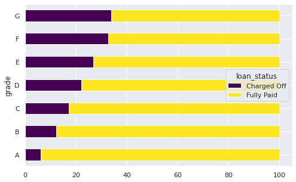

```python
# Just for fun, lets checkout effect of LC grade on loan status

custom_stacked_chart_by_loanstatues('grade', chartkind='barh')

# This confirms the value of LC grade. Worse the loan grade, higher the changes of default
```

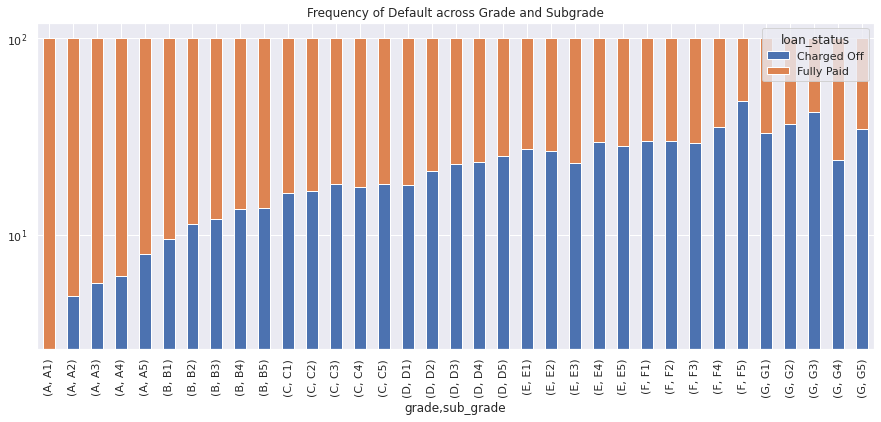

```python
pivot_df = original_data.pivot_table(index=['grade', 'sub_grade'], columns='loan_status', values='id',aggfunc=len, margins=True,margins_name='Total')
pivot_df = pivot_df.div( pivot_df.iloc[:,-1], axis=0 ).mul(100, axis=0)
pivot_df.drop(columns='Total', inplace=True)
pivot_df[0:-1].plot(kind='bar', stacked=True, grid=True, figsize=(15,6), logy=True, title='Frequency of Default across Grade and Subgrade')
plt.show()

# From this plot we can generalize, that the number of default increases as Grade-Subgrade worsens
```

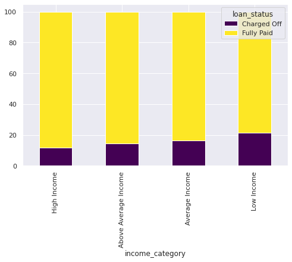

```python
# Lets check the effect of income category on percentage of defaults
custom_stacked_chart_by_loanstatues('income_category')
```

New custom metric To conclude that low income borrowers have likelihood of default is not very useful. We can try to come up with a custom metric, that would consider the assets vs the debts of the borrower, to come up with credit worthiness. Let's call this metric, secret_sauce

getscore(df) - This function is used calculate customized score

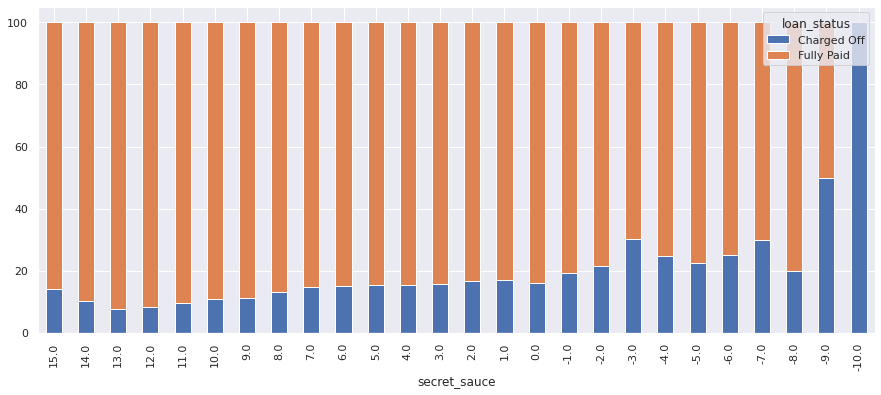

```python
custom_df = original_data[['loan_amnt','term', 'annual_inc','id', 'loan_status','home_ownership','dti_category', 'open_acc_category','income_category', 'pub_rec', 'pub_rec_bankruptcies', 'delinq_2yrs','revol_bal' ]].copy()

# Weights for values of home ownership
map_home_ownership = {'OWN':2, 'MORTGAGE': 1, 'OTHER':0, 'RENT': 0}

# Weights for  values of income category
map_income_category = {'Low Income': -1, 'Average Income':1, 'Above Average Income':2, 'High Income':3}

#Weights for  values of revolving balance
map_revol_bal = {'Low': -1, 'Average':1, 'Above Average':2, 'High':3}

#Weights for  values of dti category
map_dti = {'Low DTI':1, 'Average DTI':0, 'Above-Avg DTI':-1, 'High DTI':-2}

#Weights for  values of loan_amnt_category
map_loan_amnt_category = {'Low': 2, 'Average':1, 'Above Average':0, 'High':-1}


custom_df['revol_bal_category'] = pd.qcut(custom_df.revol_bal, q=[0,0.25,0.50,0.75,1], labels=['Low', 'Average','Above Average', 'High'])
custom_df['loan_amnt_category'] = pd.qcut(custom_df.loan_amnt, q=[0,0.25,0.50,0.75,1], labels=['Low', 'Average','Above Average', 'High'])


def getscore(df):
    score = 0
    # Asset like variables
    score = score + map_home_ownership.get(df.home_ownership,0)
    score = score + round(1.5 * map_revol_bal.get(df.revol_bal_category,0), 0)
    score = score + (2 * map_income_category.get(df.income_category, 0))

    score = score + map_loan_amnt_category.get(df.loan_amnt_category,0)
    score = score + map_dti.get(df.dti_category,0)

    # Penalty like variables
    score = score + (-2 * df.pub_rec_bankruptcies)
    score = score + (-2 * df.pub_rec)
    score = score + (-1 * df.delinq_2yrs)
    return score;
custom_df['secret_sauce'] = custom_df.apply(getscore, axis=1)

pivot_df = custom_df.pivot_table(index=['secret_sauce'], columns='loan_status', values='id',aggfunc=len, margins=True,margins_name='Total')
pivot_df = pivot_df.div( pivot_df.iloc[:,-1], axis=0 ).mul(100, axis=0)
pivot_df.drop(columns='Total', inplace=True)
pivot_df = pivot_df[0:-1]
pivot_df.sort_values('secret_sauce', ascending=False, inplace=True)
pivot_df.plot(kind='bar', stacked=True, grid=True, figsize=(15,6))
plt.show()

# Conclusion: Our custom metric column 'secret_sauce' could be used to indicate default. A negative on this metric indicates a strong chance of default
```

Conclusion After the initial Exploratory Data analysis, we can say that the chances of default increases if:

Loan purpose is among Small Business, Other, Renewable Energy and Education

Loan records has High ROI (interest rate)

Worse application Grade and Subgrade

Number of Public bankruptcies

A negative score on secret_sauce indicates high chances of default.

```python
%%shell
ipython nbconvert --to html  credit_default.ipynb
```

[output not shown]

[output cut: 109 more lines]

[output not shown]

[output not shown]